## Beta distribution plotting

I am still trying to replicate this pipeline: [methylation_seminar](http://stat540-ubc.github.io/sm08_methylation.html). After the first portion of data collection and formatting, they asked to make a plot about distribution of beta values. Expected plot is this:

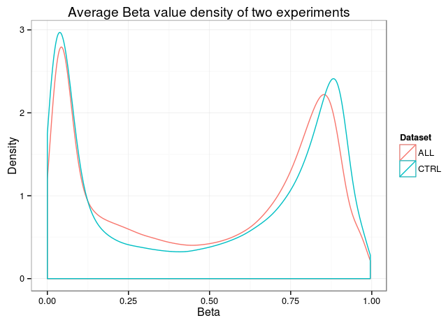

But, here is my code and result:

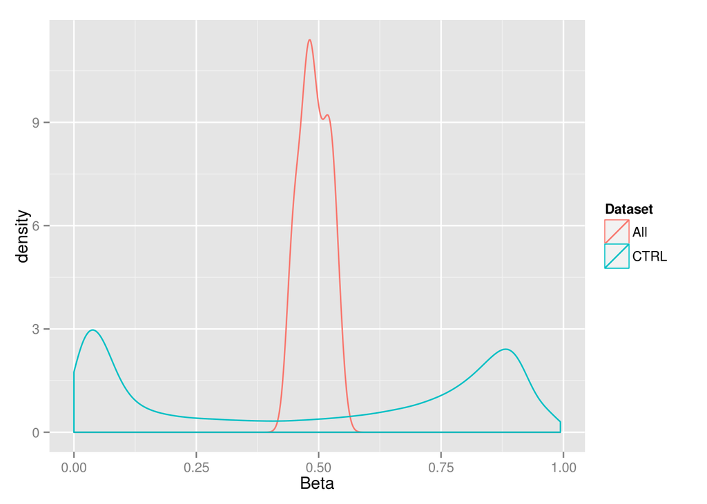

```r
library(ggplot2)
load('methyl_ALL2.Rdata')
All.beta<-data.frame(Beta=rowMeans(All.dat[,1:485577],na.rm=TRUE),Dataset=as.factor('All'))
CTRL.beta<-data.frame(Beta=rowMeans(CTRL.dat,na.rm=TRUE),Dataset=as.factor('CTRL'))
to_plot=rbind(All.beta,CTRL.beta)
ggplot(to_plot,aes(Beta,color=Dataset))+geom_density()
```

Well, they actually gave a hint saying only using rowMeans() function, further things i’ve found somewhere else. If you take a look at both summary:

```r
summary(All.beta$Beta)
```

```
##    Min. 1st Qu.  Median    Mean 3rd Qu.    Max.
##  0.4431  0.4701  0.4856  0.4910  0.5177  0.5416
```

```r
summary(CTRL.beta$Beta)
```

```
##    Min. 1st Qu.  Median    Mean 3rd Qu.    Max.
## 0.00000 0.07958 0.59090 0.49210 0.84250 0.99380
```

In experimental data(All) every row has 485577 columns, thus averaging this huge data per row shrinking its range, but in control data(CTRL), it has fewer columns with so many rows. Thus its showing wide range I guess. Anyway, I’m working on this. Just tried to experiment with rmarkdown and also keeping u updated. Thanks

## UPDATE

After some playing around i’ve switched the rowMeans() to colMeans() for All.dat. That generates the following figure which is exactly as expected! This time i’ve also added some proper labelling:

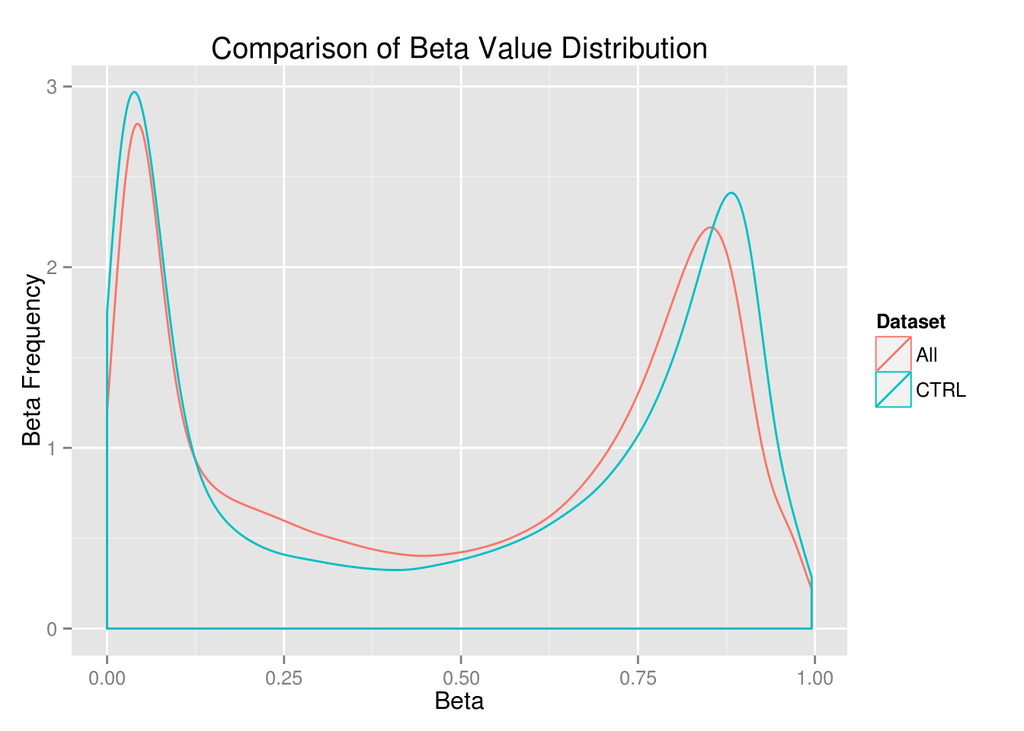

```r
All.beta<-data.frame(Beta=colMeans(All.dat[,1:485577],na.rm=TRUE),Dataset=as.factor('All'))
to_plot<-rbind(All.beta,CTRL.beta)
ggplot(to_plot,aes(Beta,color=Dataset))+geom_density()+labs(title = "Comparison of Beta Value Distribution", x="Beta",y="Beta Frequency")
```

And summary also looks good:

```r
summary(All.beta$Beta)
```

```
##      Min.   1st Qu.    Median      Mean   3rd Qu.      Max.
## 0.0007506 0.1094000 0.5730000 0.4909000 0.8174000 0.9954000
```

```r
summary(CTRL.beta$Beta)
```

```
##    Min. 1st Qu.  Median    Mean 3rd Qu.    Max.
## 0.00000 0.07958 0.59090 0.49210 0.84250 0.99380
```